# HPSP (403870) 기업 분석 보고서

Alpha Hunter Hidden Gem Week 1 — 반도체 HPA 장비 글로벌 독점

Author

Alpha Hunter × Chimera AI

Published

April 26, 2026

# 기업 개요

| 항목 | 내용 |
| --- | --- |
| **종목명** | HPSP (403870.KQ) |
| **업종** | 반도체 장비 (HPA/HPO) |
| **핵심 기술** | HPA (High Pressure Annealing), 고압수소 어닐링 |
| **시총** | 약 4.4조원 |
| **현재가** | 53,400원 |
| **PER / PBR** | 48x / 12.4x |
| **컨센서스** | Strong Buy (매수 8 / 중립 1 / 매도 0) |
| **목표가** | 44,000 ~ 70,000원 |

**핵심 투자 포인트**

글로벌 유일 HPA 장비 양산업체. 삼성 3nm GAA + TSMC 2nm 필수 장비. HBM DRAM 채택 시작. 영업이익률 50%+. 순현금 1,700억원.

## 0.1 사업 요약

HPSP는 **글로벌 유일의 HPA 장비 양산업체**다. 삼성전자 3nm GAA, TSMC 2nm 공정에 필수적인 고압수소 어닐링 장비를 독점 공급.

- **삼성전자** 3nm GAA 공정 필수
- **TSMC** 2nm 공정 채택 진행
- **HBM DRAM** 신규 채택
- **imec** 공동개발 HPO 차세대 시장 개척

# 1 실적 분석

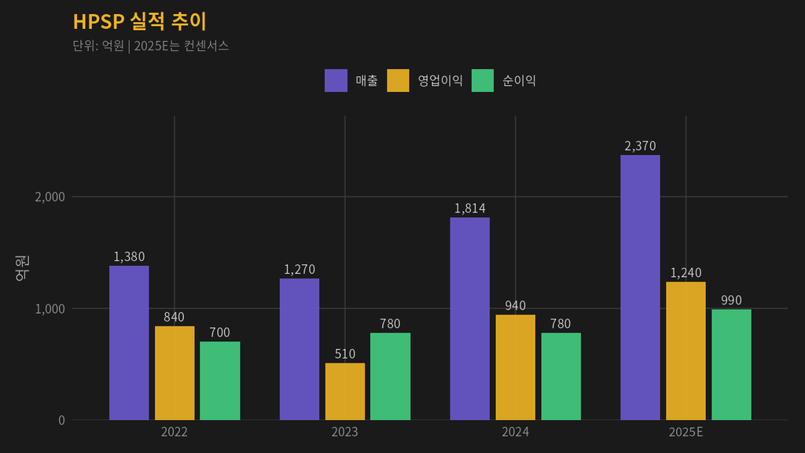

Figure 1: HPSP 매출·영업이익·순이익 추이

[output not shown]

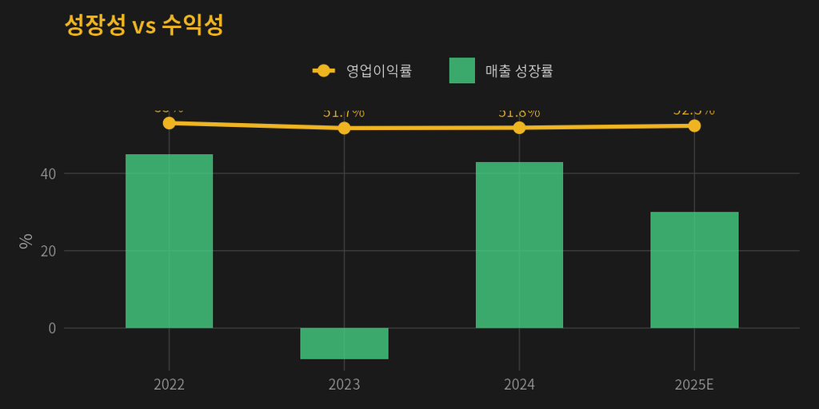

Figure 2: 매출 성장률 vs 영업이익률

# 2 리스크 분석

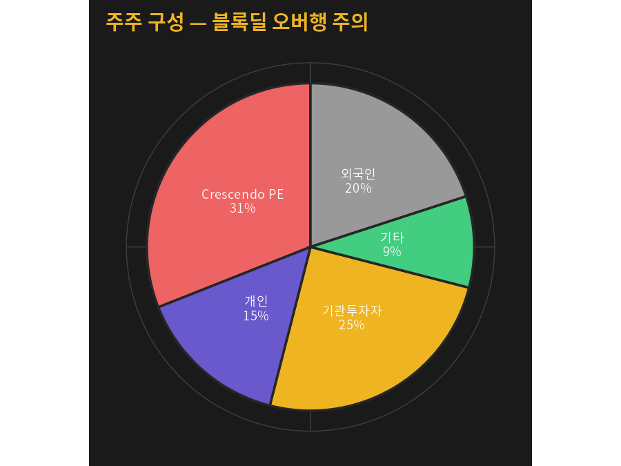

Figure 3: HPSP 주주 구성

- **Crescendo PE 31%** — 블록딜 오버행
- **삼성 의존도** ~70%
- **주문 불규칙성** — 분기별 변동
- **밸류에이션** — PER 48x

# 3 투자자 렌즈

## 3.1 워런 버핏 — “경제적 해자 + 가치”

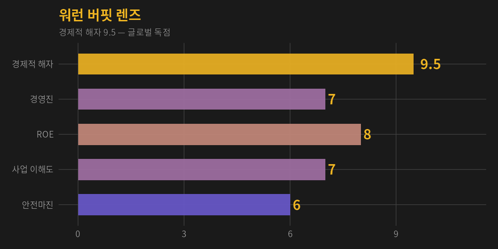

Figure 4: 워런 버핏 렌즈 평가

| 항목 | 점수 | 평가 |
| --- | --- | --- |
| 경제적 해자 | **9.5** | 글로벌 독점, 진입장벽 극높음 |
| 경영진 | 7.0 | 삼성/TSMC/imec 파트너 |
| ROE | 8.0 | 순현금 + 고마진 |
| 사업 이해도 | 7.0 | 기술 난이도 높음 |
| 안전마진 | 6.0 | PER 48x |

## 3.2 피터 린치 — “10배 주식 가능성”

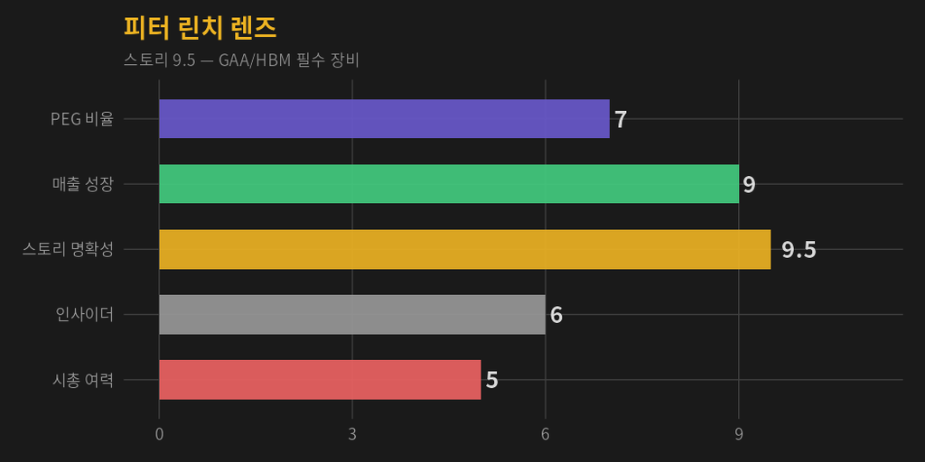

Figure 5: 피터 린치 렌즈

# 4 종합 판정

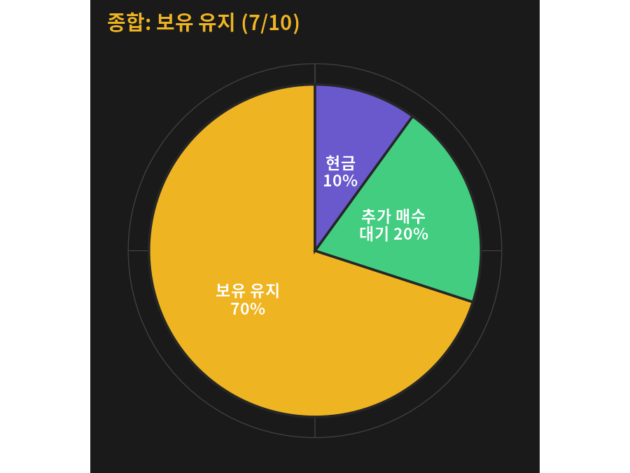

Figure 6: 투자 비중 배분

| 항목 | 가격 | 비고 |
| --- | --- | --- |
| 매수가 | 50,400원 | 현재 **+5.95%** |
| 목표가 | 60,000원 | Forward PE |
| 손절가 | 40,000원 | -20% 하방 |

**액션 플랜**

1. **보유 유지** — 실적 양호, 독점 건재
2. 5/14 실적발표 전후 변동성 주의
3. Crescendo PE 블록딜 시 저점 매수
4. 목표가 시 30% 부분 매도

*가상 투자 시뮬레이션 목적. 실제 투자 권유가 아닙니다.*

*Alpha Hunter × Chimera AI | Vibe Investing Framework*